# Case Study 5.1 - Identifying New Genes that Cause Autism

Nguyen Le Thien An

May 11, 2019

## DATA: PROTEIN-PROTEIN INTERACTION NETWORK

For this case study, we will work with the BioGRID (http://thebiogrid.org) dataset, which makes available the protein-protein interaction network for humans. For your convenience, we provide a sample of this data in the file entitled: ’BIOGRID.txt" for use in the rest of this tutorial.

Note that for this tutorial, you will need the igraph library for R. You can install it by invoking the following line of code and choosing the mirror closest to you:

```r
# install.packages("igraph")
# install.packages("sna")
```

The following lines of code in R will allow you to work with this protein-protein interaction data and the network in R:

```r
library(igraph)
biogrid <- read.delim("./BIOGRID.txt",stringsAsFactors = F)

#View biogrid
names(biogrid)
```

```
##  [1] "X.BioGRID.Interaction.ID"     "Entrez.Gene.Interactor.A"
##  [3] "Entrez.Gene.Interactor.B"     "BioGRID.ID.Interactor.A"
##  [5] "BioGRID.ID.Interactor.B"      "Systematic.Name.Interactor.A"
##  [7] "Systematic.Name.Interactor.B" "Official.Symbol.Interactor.A"
##  [9] "Official.Symbol.Interactor.B" "Synonyms.Interactor.A"
## [11] "Synonyms.Interactor.B"        "Experimental.System"
## [13] "Experimental.System.Type"     "Author"
## [15] "Pubmed.ID"                    "Organism.Interactor.A"
## [17] "Organism.Interactor.B"        "Throughput"
## [19] "Score"                        "Modification"
## [21] "Phenotypes"                   "Qualifications"
## [23] "Tags"                         "Source.Database"
```

```r
attach(biogrid)

HSnet <- graph.data.frame(data.frame(Entrez.Gene.Interactor.A,Entrez.Gene.Interactor.B),directed=F)
```

Summary info of the data:

```r
# You can uncomment the following line to plot the network, but it takes a long time
# plot(HSnet)

A <- get.adjacency(HSnet)

# multiple edges
A[1:15,1:15]
```

```
## 15 x 15 sparse Matrix of class "dgCMatrix"
##
## 6416  1 . . . . . . . 1 . .  . . 2 .
## 84665 . . . . . . . . . . .  . . . .
## 90    . . 1 . . . . . . . .  . . . .
## 2624  . . . . . . . . . . .  1 . . .
## 6118  . . . . . . . 1 1 . .  . . . .
## 375   . . . . . 1 1 . . . .  . . . .
## 377   . . . . . 1 . . . . .  . . . .
## 54464 . . . . 1 . . . . . .  . . . .
## 351   1 . . . 1 . . . 1 . .  . . . .
## 333   . . . . . . . . . . .  . . . .
## 10370 . . . . . . . . . . .  8 . . .
## 2033  . . . 1 . . . . . . 8 17 . . .
## 338   . . . . . . . . . . .  . 1 . .
## 409   2 . . . . . . . . . .  . . 1 .
## 1436  . . . . . . . . . . .  . . . .
```

Simplify the network graph:

```r
# the following is FALSE if the graph is not simple
is.simple(HSnet)
```

```
## [1] FALSE
```

```r
# remove multiple edges and self-loops
HSnet <- simplify(HSnet, remove.multiple = TRUE, remove.loops = TRUE, edge.attr.comb = getIgraphOpt("edge.attr.comb"))

is.simple(HSnet)
```

```
## [1] TRUE
```

Data after manipulation:

```r
A <- get.adjacency(HSnet)

# only single edges now
A[1:15,1:15]
```

```
## 15 x 15 sparse Matrix of class "dgCMatrix"
##
## 6416  . . . . . . . . 1 . . . . 1 .
## 84665 . . . . . . . . . . . . . . .
## 90    . . . . . . . . . . . . . . .
## 2624  . . . . . . . . . . . 1 . . .
## 6118  . . . . . . . 1 1 . . . . . .
## 375   . . . . . . 1 . . . . . . . .
## 377   . . . . . 1 . . . . . . . . .
## 54464 . . . . 1 . . . . . . . . . .
## 351   1 . . . 1 . . . . . . . . . .
## 333   . . . . . . . . . . . . . . .
## 10370 . . . . . . . . . . . 1 . . .
## 2033  . . . 1 . . . . . . 1 . . . .
## 338   . . . . . . . . . . . . . . .
## 409   1 . . . . . . . . . . . . . .
## 1436  . . . . . . . . . . . . . . .
```

```r
# for this application, we remove nodes of very high degree; these are usually house-keeping
# genes that are necessary to keep a cell alive, but are usually not specific to a particular
# disease.
overly.attached.proteins <- which(degree(HSnet)>1000)
HSnet <- delete.vertices(HSnet, overly.attached.proteins )
# the following is TRUE if the graph is connected.
is.connected(HSnet)
```

```
## [1] FALSE
```

## DATA: GENES CAUSING AUTISM

We now need to identify a list of genes that are known to cause Autism. Such data is provided by SFARI Gene (https://gene.sfari.org/autdb/Welcome.do). We provide sample files from this database entitled: “gene-id-table.txt” and “gene-score.csv”. You can use these files in the rest of this tutorial. The following lines of code in R will guide you in extracting information about the genes that are known to cause Autism:

```r
# read the gene-id table
gene.table <- read.delim("gene-id-table.txt")
names(gene.table)
```

```
## [1] "Symbol" "ID"
```

```r
# read the scores for Autism
gene.score<-read.csv("gene-score.csv",stringsAsFactors=F)
attach(gene.score)
names(gene.score)
```

```
## [1] "Gene.Symbol"   "Gene.Name"     "Score.Details" "Score"
## [5] "Evidence"      "References"    "Scored.By"
```

```r
# display the scores
unique(Score)
```

```
##  [1] "4"  "3"  "1S" "S"  "6"  "5"  "1"  "2S" "2"  "3S" "4S"
```

Project on HSnet

```r
# identify the genes that have significant scores
signif.scores<-c("3","1S","1","2S","2","3S")
signif.genes<-Gene.Symbol[which(Score %in% signif.scores)]
signif.EIDs <- gene.table[which(gene.table[,1] %in% signif.genes),2]

# Now use the protein interaction network HSnet, created previously, to determine the genes
# that are present in the network and known to cause Autism
geneEIDs <- as.numeric(V(HSnet)$name)
HSnetN<-HSnet
V(HSnetN)$name<-1:length(V(HSnet))
signif.ids<-which(geneEIDs %in% signif.EIDs)

length(signif.ids)
```

```
## [1] 100
```

## BUILDING AN AUTISM INTERACTOME

Now that we have a protein-protein interaction network and have also identified the genes or nodes in this network that are known to cause Autism, we can build an “Autism Interactome”: We want to determine the smallest subnetwork of the full protein-protein interaction network that contains the Autism genes. This will help us to determine new candidate genes for Autism, since these are genes that are central in this Autism Interactome. We build the Autism Interactome using `Steiner Trees`, i.e. the subnetwork of shortest length that connects a given set of nodes. We have provided a script in R called “steiner_tree.R” for your convenience. This script should be placed in the same directory as your own R script. You can then use it, as shown below.

```r
source('steiner_tree.R')
# Identify the Steiner Tree
HS.stree <- steiner_tree(terminals=signif.ids, graph=HSnetN)

# Output the overlap between significant Autism and vertices in the Steiner Tree
length(intersect(signif.ids,V(HS.stree)$name))
```

```
## [1] 95
```

Visualization:

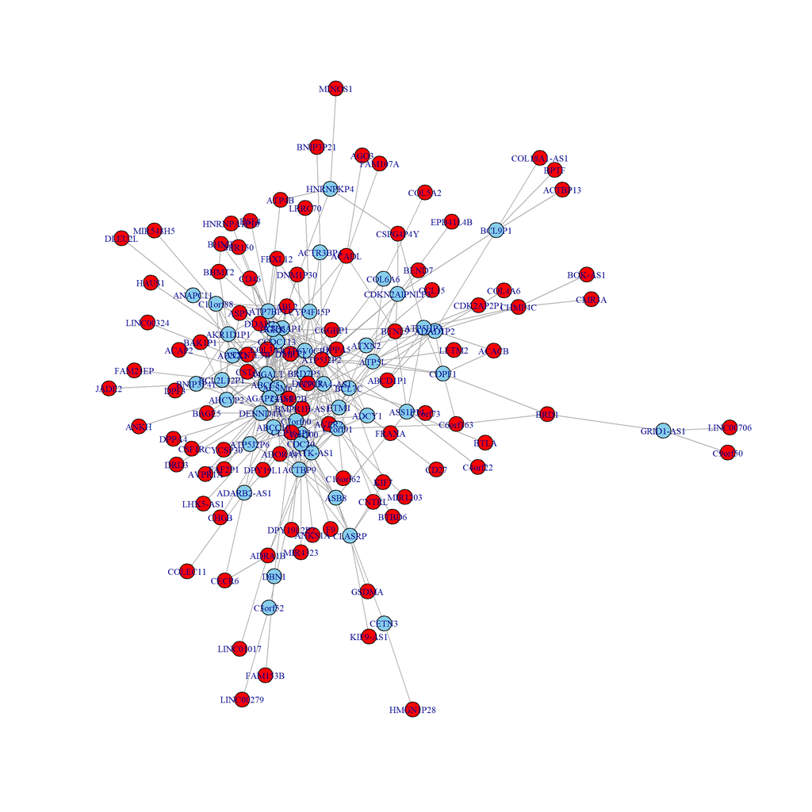

```r
labels<-gene.table[as.numeric(V(HS.stree)$name),1]
labels<-as.character(labels)

# identify the genes that have significant scores, and assign the color "red" to them
colors<-rep("skyblue",length(V(HS.stree)))
colors[which(as.numeric(V(HS.stree)$name) %in% signif.ids)] = "red"

# assign colors to the vertices of the tree
V(HS.stree)$color = colors

# plot and save to file
#pdf("ASD_interactome.pdf",width=12, height=12)
#plot(HS.stree,vertex.label=labels,vertex.size=5,vertex.label.cex=0.8)
#dev.off()

plot(HS.stree,vertex.label=labels,vertex.size=5,vertex.label.cex=0.8)
```

## ANALYSIS AND PROPERTIES OF THE AUTISM INTERACTOME

We can now analyze the properties of the Autism Interactome and compare it to randomly generated Interactomes. The following lines of code in R will help us with these comparisons. Note that you will need the `"sna"` library for R. You can download and install it by calling the following function: `install.packages("sna")` and then choosing the nearest mirror to your location.

```r
library(sna, quietly=TRUE)

# a function that computes the connectivity scores for a network
# here the scores are diameters of the network and average geodesic distance between any two nodes
c.scores<-function(graph) {
n<-length(V(graph))
sp<-shortest.paths(graph)
neighbors<-sum(sp==1)/2
neighbors2<-sum(sp==2)/2
return(c(2*neighbors/(n*(n-1)),2*neighbors2/(n*(n-1))))
}
```

```r
clus<-clusters(HSnetN, mode=c("weak"))
connected.ids<-which(clus$membership==1)
length(connected.ids)
```

```
## [1] 17796
```

The efficiencies and connectivity scores for each of the N random graphs:

```r
# Generate N randomly chosen subnetworks. Note: this will take a while if N is set large.
N<-50
strees<-list(N)
effs<-numeric(N)
nei<-numeric(N)
nei2<-numeric(N)

for (i in 1:N){
  new.ids<-sample(x=connected.ids,size=length(signif.ids))
  strees[[i]] <- steiner_tree(terminals=new.ids, graph=HSnetN)
  effs[i]<-efficiency(get.adjacency(strees[[i]],sparse=F))
  cs<-c.scores(strees[[i]])
  nei[i]<-cs[1]
  nei2[i]<-cs[2]
}

# print the efficiencies and connectivity scores for each of the N random graphs
effs
```

```
##  [1] 0.9819344 0.9791697 0.9842038 0.9787037 0.9803719 0.9817771 0.9822877
##  [8] 0.9758238 0.9822209 0.9808025 0.9788869 0.9795875 0.9793962 0.9783487
## [15] 0.9799216 0.9829870 0.9729351 0.9830314 0.9786420 0.9772222 0.9746994
## [22] 0.9795878 0.9790240 0.9764062 0.9836511 0.9748245 0.9792205 0.9810373
## [29] 0.9782204 0.9822041 0.9738889 0.9832821 0.9848064 0.9764989 0.9731698
## [36] 0.9809356 0.9779144 0.9802674 0.9794612 0.9743356 0.9793664 0.9785050
## [43] 0.9819918 0.9810555 0.9826963 0.9775926 0.9788927 0.9800622 0.9770862
## [50] 0.9844222
```

```r
nei
```

```
##  [1] 0.02340223 0.02669360 0.02114517 0.02670350 0.02516692 0.02361727
##  [7] 0.02339024 0.02962777 0.02329715 0.02461633 0.02664355 0.02617473
## [13] 0.02598506 0.02711694 0.02574271 0.02253539 0.03278803 0.02265089
## [19] 0.02676489 0.02817680 0.03087028 0.02600985 0.02680354 0.02923780
## [25] 0.02184420 0.03071429 0.02628071 0.02423714 0.02733766 0.02337662
## [31] 0.03149171 0.02203290 0.02082102 0.02892613 0.03242309 0.02422723
## [37] 0.02770580 0.02543180 0.02610390 0.03139575 0.02595628 0.02684201
## [43] 0.02346369 0.02439479 0.02285568 0.02780847 0.02683179 0.02563579
## [49] 0.02837236 0.02095718
```

```r
nei2
```

```
##  [1] 0.1276431 0.1556886 0.1142195 0.1687538 0.1485619 0.1247040 0.1293185
##  [8] 0.1634549 0.1425125 0.1338244 0.1447098 0.1450052 0.1401251 0.1472601
## [15] 0.1353004 0.1128039 0.1917160 0.1258234 0.1459791 0.1548803 0.1687356
## [22] 0.1426601 0.1474194 0.1622530 0.1207708 0.1659740 0.1376881 0.1223482
## [29] 0.1503896 0.1143506 0.1702271 0.1354289 0.1025287 0.1638113 0.1870308
## [36] 0.1282651 0.1558700 0.1413709 0.1399351 0.1867038 0.1426705 0.1425569
## [43] 0.1182495 0.1286778 0.1247432 0.1480663 0.1423461 0.1371549 0.1593748
## [50] 0.1152345
```

The efficiency score and connectivity scores for the Autism Interactome:

```r
# Finally, print the efficiency score and connectivity scores for the Autism Interactome
efficiency(get.adjacency(HS.stree,sparse=F))
```

```
## [1] 0.9723703
```

```r
c.scores(HS.stree)
```

```
## [1] 0.03438228 0.17686480
```

## IDENTIFYING NEW CANDIDATE GENES

Next, we would like to use the Autism Interactome to identify new candidate genes that could cause Autism. We do this using some of the centrality measures discussed in this module. In particular, nodes with high betweenness centrality are good candidates for Autism, since these are genes that lie on the largest number of shortest paths between any pair of genes in the Autism Interactome, i.e. these are nodes through which a lot of information flows. Hence, if genes with a high betweenness centrality have a defect, then it is to be expected that this will cause changes in the expression of many genes in the Autism Interactome, in particular also of the already known causative genes for Autism.

The following lines of code in R can help identify the vertices with the highest betweeness centrality in the Steiner Tree, which are not already known to be significant for Autism:

```r
# compute the betweeness centrality scores for each node
betweeness_centrality_scores = igraph::betweenness(HS.stree)

# now identify only those NOT already known to be significant
significant_centrality = c()
significant_names = c()
count = 0
for (i in 1:length(betweeness_centrality_scores)){
  if (!(as.numeric(names(betweeness_centrality_scores[i])) %in% signif.ids)) {
    significant_centrality = c(significant_centrality, betweeness_centrality_scores[i])
    significant_names = c(significant_names, names(betweeness_centrality_scores[i]))
  }
}


# sort
significant_centrality = sort(significant_centrality, decreasing=TRUE)
significant_labels = as.character(gene.table[as.numeric(significant_names),1])

length(significant_centrality)
```

```
## [1] 49
```

```r
significant_centrality
```

```
##       342        11      1837      2700       241      6143      1878
## 911.28197 893.83679 882.37168 862.99271 851.10922 817.03065 700.29814
##      2584       257      3602      1558        41        76      2112
## 673.66693 604.30027 587.42287 577.30857 574.83032 567.86269 547.61472
##      4070      6283      4059        83      2115      2407      1791
## 520.26867 509.53809 494.70380 455.35270 427.43333 422.06682 406.86997
##      1778      1892       560      1804      1634       741      1852
## 398.18244 391.75469 383.70973 378.37214 369.81060 320.83649 300.54679
##     10222      2820       413      1906      7793      4605      5766
## 283.00000 254.09930 236.08722 234.33538 229.16060 222.16117 209.57571
##      2102       623      2965      3918     11327       423      2339
## 197.85864 194.51312 183.62970 179.49787 175.73871 158.40107 145.64336
##       312       922      2715      4285      4943      5878      1789
## 142.00000 142.00000 142.00000 142.00000 142.00000 142.00000  54.39843
```

```r
significant_labels
```

```
##  [1] "A4GALT"       "AATK-AS1"     "ABCC5"        "ABCC10"
##  [5] "ACSM6"        "ACTBP9"       "ACTR3BP4"     "ADAD1P2"
##  [9] "ADARB2-AS1"   "ADCY1"        "AGAP2-AS1"    "AHCYP2"
## [13] "AKR1D1P1"     "ANAPC11"      "ASB8"         "ASS1P14"
## [17] "ATP5HP3"      "ATP5J2P6"     "ATP5L"        "ATP6AP1"
## [21] "ATP6V0CP1"    "ATP7BP1"      "ATP13A4-AS1"  "ATXN2"
## [25] "AUNX1"        "BCL2L12P1"    "BCL7C"        "BCL9P1"
## [29] "BNIP3P41"     "BRD7P5"       "C1orf100"     "C2orf91"
## [33] "C3orf52"      "C7orf60"      "C11orf88"     "CCDC113"
## [37] "CDC20"        "CDKN2AIPNLP3" "CDPF1"        "CETN3"
## [41] "CLASRP"       "COL6A6"       "CYP4F45P"     "DBN1"
## [45] "DENND4A"      "DGKK"         "ETM1"         "GRID1-AS1"
## [49] "HNRNPKP4"
```